# Random Forest Prediction Model for Smartphone App Downloads

## ROC Curve and AUC

We will now plot the ROC curve and calculate the AUC (Area Under the Curve) for the model.

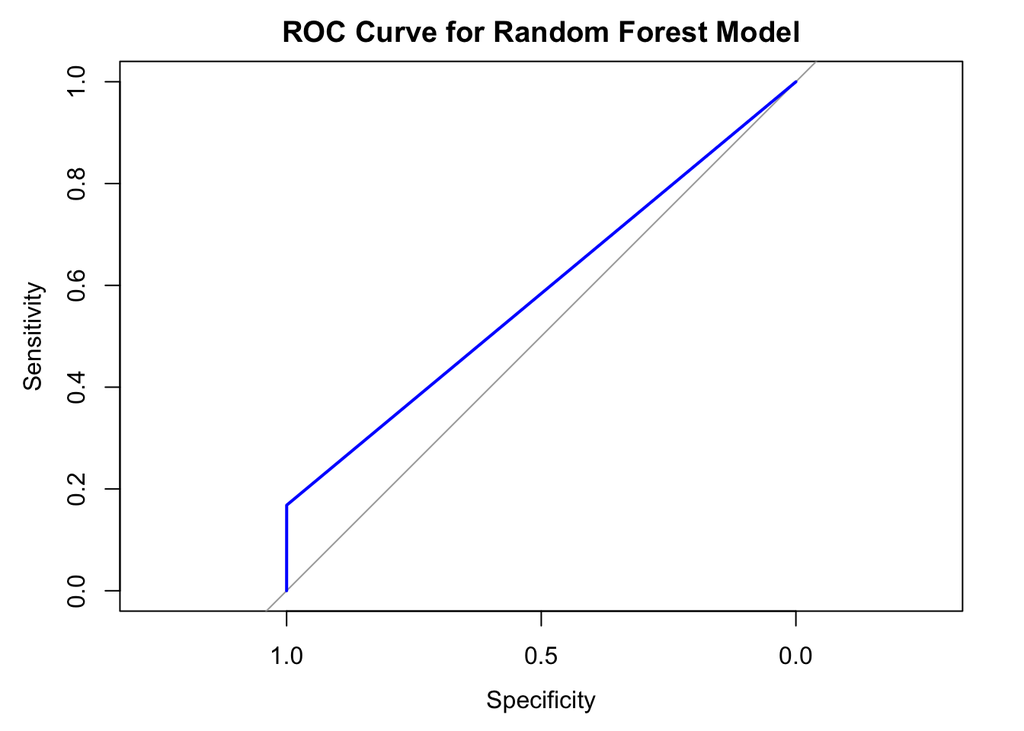

```r
roc_curve <- roc(testData$V8, as.numeric(predictions))
plot(roc_curve, col = "blue", main = "ROC Curve for Random Forest Model")
```

```r
auc_value <- auc(roc_curve)
cat("AUC:", auc_value, "\n")
```

```
## AUC: 0.5839906
```

The picture shows the ROC curve for a Random Forest model used for classification. The bottom part (x-axis) shows specificity, which is how well the model avoids false positives. The side part (y-axis) shows sensitivity, which is how well the model correctly identifies true positives. The blue line shows how well the model is doing, and the gray diagonal line shows the line for random guessing. The ROC curve is near the diagonal line, which means the Random Forest model is not very good at telling apart different groups in this dataset. An ideal ROC curve would stay close to the top-left corner, showing that the model is good at correctly identifying both positive and negative cases. However, since this curve is close to the diagonal line, it suggests that the model is not doing a great job of telling the difference between the classes.

The AUC for the model is 0.5840, indicating that the model has a slightly better than random performance.

## Hyperparameter Tuning

To improve the model, we perform hyperparameter tuning using caret and select the best mtry value.

```r
tuneGrid <- expand.grid(mtry = 2:5)
control <- trainControl(method = "cv", number = 5)

rf_tuned <- train(V8 ~ V1 + V2 + V3 + V4 + V5,
                  data = trainData,
                  method = "rf",
                  tuneGrid = tuneGrid,
                  trControl = control)
print(rf_tuned)
```

```
## Random Forest
##
## 50001 samples
##     5 predictor
##     2 classes: '0', '1'
##
## No pre-processing
## Resampling: Cross-Validated (5 fold)
## Summary of sample sizes: 40001, 40000, 40001, 40001, 40001
## Resampling results across tuning parameters:
##
##   mtry  Accuracy  Kappa
##   2     0.99792   0.2534558
##   3     0.99774   0.3113615
##   4     0.99776   0.3215204
##   5     0.99758   0.3300253
##
## Accuracy was used to select the optimal model using the largest value.
## The final value used for the model was mtry = 2.
```